# Discussion Section Worksheet #7

Anupama Bhatta

November 7, 2023

# Learning objectives

- Understand bootstrap distributions and the bootstrapping procedure
- Articulate the relationship between bootstrap distributions and confidence intervals
- Interpret confidence intervals

## Returning to flight delays

We're going to stay with our dataset of flight delays. Last time, we practiced sampling the whole dataset. But what if we only had access to a very small number of observations, and couldn't get a new sample (this might happen if you have limited resources to conduct a study)? Today, we'll work with a dataframe called `fifty_alaska_flights`- and we're going to imagine these fifty flights are the entirety of our data.

```r
set.seed(2)
library(moderndive)
library(ggplot2)
library(dplyr)
library(infer)

fifty_alaska_flights <- alaska_flights %>%
  na.omit %>%
  sample_n(50)
```

## Calculate the average flight delay in these 50 flights.

```r
avg_flight_delay <- fifty_alaska_flights %>%
  summarize (mean = mean(dep_delay))
avg_flight_delay
```

```
## # A tibble: 1 × 1
##    mean
##   <dbl>
## 1  4.58
```

But is this average very representative of the true typical flight delay? What if we had collected a different 50 flights- would we get a very different answer? Unfortunately, we can't go out and collect more data. So what do we do?

## Bootstrap to the rescue

Here is where the resampling, or bootstrapping, procedure (bootstrapping for short) shines.

First, what let's resample our fifty flights one time.

```r
resample_one <- fifty_alaska_flights %>%
  rep_sample_n(size = 50, replace = TRUE)
resample_one
```

```
## # A tibble: 50 × 20
## # Groups:   replicate [1]
##    replicate  year month   day dep_time sched_…¹ dep_d…² arr_t…³ sched…⁴ arr_d…⁵
##        <int> <int> <int> <int>    <int>    <int>   <dbl>   <int>   <int>   <dbl>
##  1         1  2013     8    19      728      720       8     953    1025     -32
##  2         1  2013     8    30      721      720       1    1003    1025     -22
##  3         1  2013     4     2      719      725      -6    1007    1030     -23
##  4         1  2013     7    31     1835     1825      10    2201    2147      14
##  5         1  2013     5    30     1827     1820       7    2105    2133     -28
##  6         1  2013     9     6     1824     1835     -11    2123    2158     -35
##  7         1  2013     7    16      717      720      -3     945    1025     -40
##  8         1  2013     4    18      834      725      69    1141    1015      86
##  9         1  2013     5    12     1813     1820      -7    2105    2133     -28
## 10         1  2013     7    25     1815     1825     -10    2116    2147     -31
## # … with 40 more rows, 10 more variables: carrier <chr>, flight <int>,
## #   tailnum <chr>, origin <chr>, dest <chr>, air_time <dbl>, distance <dbl>,
## #   hour <dbl>, minute <dbl>, time_hour <dttm>, and abbreviated variable names
## #   ¹sched_dep_time, ²dep_delay, ³arr_time, ⁴sched_arr_time, ⁵arr_delay
## # ℹ Use `print(n = ...)` to see more rows, and `colnames()` to see all variable names
```

How does the resampled data look compared to `fifty_alaska_flights`? What is different about it? *There are two major difference between the original dataset and the resampled dataset. First, the resampled data contains a column called "replicate", which indicates how many times we resampled our original dataset. Second, the resampled dataset can have duplicates as we are sampling with replacement.*

What is the mean of this resampled data?

```r
avg_resampled_flight_delay <- resample_one %>%
  summarize (mean = mean(dep_delay))
avg_resampled_flight_delay
```

```
## # A tibble: 1 × 2
##   replicate  mean
##       <int> <dbl>
## 1         1  2.96
```

### Resample 1000 times

Now, repeat the resampling procedure 1000 times. For each resample, calculate the average departure delay. If this seems overwhelming, take a look at some of the code recipes in Chapter 8.2.

```r
bootstrap_samples_infer <- fifty_alaska_flights %>%
  specify(response = dep_delay) %>%
  generate(reps = 1000, type = "bootstrap") %>%
  calculate(stat = 'mean')
bootstrap_samples_infer
```

```
## # A tibble: 1,000 × 2
##    replicate  stat
##        <int> <dbl>
##  1         1  5.48
##  2         2  2.92
##  3         3  0.82
##  4         4  2.38
##  5         5  1.1
##  6         6  3.66
##  7         7  7.32
##  8         8  2.08
##  9         9  2.72
## 10        10  7.44
## # … with 990 more rows
## # ℹ Use `print(n = ...)` to see more rows
```

In plain language, describe each line of your resampling recipe above. What does this step do? **Here, I am taking my original dataset fifty_alaska_flights, and specifying that I want the dep_delay column. Inside the generate() function, the first argument is reps, which sets the number of replicates I would like to generate. Since we want to resample the 50 flights in fifty_alaska_flights with replacement 1000 times, we set reps = 1000. Lastly, we set this to type = "bootstrap" indicating that we want to perform bootstrap resampling. After we generate() many replicates of bootstrap resampling with replacement, we next want to summarize each of the 1000 resamples of size 50 to a single sample statistic value. In this case, I want to calculate the mean value for each bootstrap resample of size 50. To do so, we set the stat argument to "mean".**

Finally, visualize the bootstrap distribution of the average flight delay. This should be a histogram.

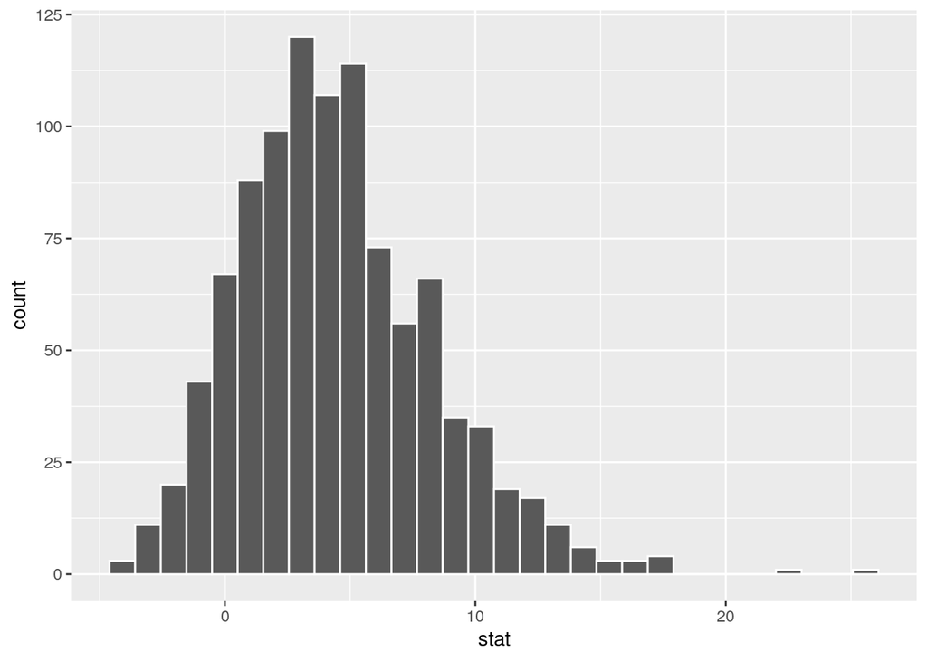

```r
ggplot(data = bootstrap_samples_infer, aes(x = stat))+
  geom_histogram(color = "white")
```

What does this distribution visualize? What is on the x- and y-axes, and what does the height of a bar indicate?** *The distribution visualizes the column stat on the x-axis, which was created in the bootstrapping pipeline and is essentially calculating the average departure delay for each resampling procedure repeated 1000 times. The y-axis represents the frequency or count of observations falling into each bin or interval on the x-axis, and the height of each bar in the histogram will represent how many times a particular average departure delay value occurred in your bootstrapping procedure.*

### Visualize a confidence interval

Using the helper functions from the `infer` library, can you calculate the 95% confidence interval? And then visualize it? Any of the methods presented in the textbook are allowed.

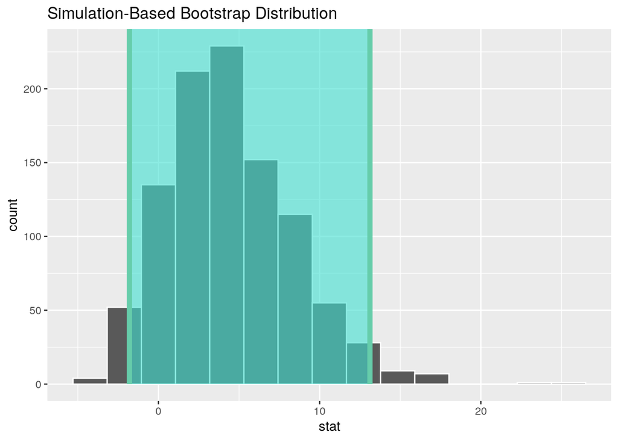

```r
confidence_interval <- bootstrap_samples_infer %>%
  get_confidence_interval(level = 0.95, type = 'percentile')

visualise(bootstrap_samples_infer) +
  shade_ci(endpoints = confidence_interval)
```

Based on the visual above, what range do you expect the true flight delay to fall in? *The range is apporximately between -2 and 13 minutes.*

If we had used a 90% confidence interval instead of a 95% interval, would that be wider or narrower? What would that mean for how sure we are about the average flight delay for all Alaska flights? *If we had used a 90% confidence interval instead of a 95% interval, the range would be narrower.*

### Comparing the bootstrap distribution to the sample distribution

What's the relationship between the bootstrap distribution you made here and the sample distribution you made last week? In what ways are they similar and different? *The bootstrap distribution is a resampled version of the original sample and is primarily used for statistical inference, while the sample distribution is the distribution of the actual data and is used for understanding the characteristics of the observed data. They are similar in that they both involve data analysis, but they serve different purposes and are obtained differently.*

## Check your comprehension

You don't have to do anything here, but make sure you can define the following concepts. Practice identifying what they refer to in the textbook example and in the example we've done in this worksheet.

- Resampling
- Bootstrap distribution
- Confidence interval